# Ts forecasting model for household energy consumption

# Setup

```r
library(tidyverse)
library(ggplot2)
library(lubridate)
library(tsibble) # to convert to tsibble (ts data)
library(slider) # for rolling average
library(feasts) # for ts analyses
library(fable) # for forecasting
library(urca) # support function for ARIMA model?
#library(GGally) # for ggpairs to explore correlations
#library(psych) # for pairplots to explore correlations
```

```r
# household energy consumption by date (from Kaggle)
daily_energy <- read_csv("../3_raw_data/london_energy.csv") %>%
  janitor::clean_names()
```

```r
# trim dates - because of lack of data at start & unusual end value
  # start in Winter 2011 (91 households by that point)
  # and remove last date, very low median value (unusual)
daily_energy_trim <- daily_energy %>%
  filter(date >= "2011-12-01" & date < "2014-02-28")

daily_energy_trim
```

| lc_lid | date | kwh |
| --- | --- | --- |
| MAC000002 | 2012-10-12 | 7.098 |
| MAC000002 | 2012-10-13 | 11.087 |
| MAC000002 | 2012-10-14 | 13.223 |
| MAC000002 | 2012-10-15 | 10.257 |
| MAC000002 | 2012-10-16 | 9.769 |
| MAC000002 | 2012-10-17 | 10.885 |
| MAC000002 | 2012-10-18 | 10.751 |
| MAC000002 | 2012-10-19 | 8.431 |
| MAC000002 | 2012-10-20 | 17.578 |
| MAC000002 | 2012-10-21 | 24.490 |

[output cut: 990 more lines]

```r
total_days <- as.numeric(max(daily_energy_trim$date) - min(daily_energy_trim$date) + 1)
total_days
```

```
[1] 820
```

```r
daily_energy_trim %>%
  summarise(num_obs = n(), .by = lc_lid)
```

| lc_lid | num_obs |
| --- | --- |
| MAC000002 | 504 |
| MAC000003 | 739 |
| MAC000004 | 661 |
| MAC000005 | 637 |
| MAC000006 | 760 |
| MAC000007 | 522 |
| MAC000008 | 544 |
| MAC000009 | 526 |
| MAC000010 | 522 |
| MAC000011 | 494 |

[output cut: 990 more lines]

5,566 households in this data, varying number of observations each over total time frame of 820 days

```r
# generate household stats
hhold_stats <- daily_energy_trim %>%
  mutate(zero_kwh = if_else(kwh == 0, T, F)) %>%
  group_by(lc_lid) %>%
  summarise(num_values = n(),
            num_zeros = sum(zero_kwh),
            min_value = min(kwh),
            max_value = max(kwh),
            range = (max(kwh) - min(kwh)),
            median_kwh = median(kwh),
            iqr = IQR(kwh),
            mean_kwh = mean(kwh),
            sd = sd(kwh)
            ) %>%
  mutate(pc_missing_days = (100 * (total_days - num_values) / total_days), .after = lc_lid) %>%
  mutate(pc_zero_values = (100 * num_zeros / num_values), .after = pc_missing_days) %>%
  ungroup()

hhold_stats
```

| lc_lid | pc_missing_days | pc_zero_values | num_values | num_zeros | min_value | max_value | range | median_kwh | iqr | mean_kwh | sd |
| --- | --- | --- | --- | --- | --- | --- | --- | --- | --- | --- | --- |
| MAC000002 | 38.5365854 | 0.0000000 | 504 | 0 | 0.186 | 39.284 | 39.098 | 11.2625 | 4.44600 | 12.09992857 | 4.4750683 |
| MAC000003 | 9.8780488 | 0.0000000 | 739 | 0 | 1.452 | 50.759 | 49.307 | 13.2600 | 11.02000 | 19.08564682 | 11.6101884 |
| MAC000004 | 19.3902439 | 0.1512859 | 661 | 1 | 0.000 | 7.354 | 7.354 | 1.6390 | 0.22900 | 1.69534947 | 0.4280006 |
| MAC000005 | 22.3170732 | 0.0000000 | 637 | 0 | 0.032 | 16.708 | 16.676 | 4.5170 | 1.44100 | 4.57077551 | 1.4609788 |
| MAC000006 | 7.3170732 | 0.0000000 | 760 | 0 | 0.001 | 6.636 | 6.635 | 2.8800 | 0.72950 | 2.85298553 | 0.8769952 |
| MAC000007 | 36.3414634 | 0.0000000 | 522 | 0 | 2.715 | 41.858 | 39.143 | 9.2030 | 2.59425 | 9.49022414 | 3.8569165 |
| MAC000008 | 33.6585366 | 0.0000000 | 544 | 0 | 0.287 | 39.099 | 38.812 | 17.6015 | 6.70650 | 17.36214522 | 4.9720105 |
| MAC000009 | 35.8536585 | 0.0000000 | 526 | 0 | 3.486 | 15.527 | 12.041 | 8.5625 | 2.00825 | 8.58340494 | 1.7225841 |
| MAC000010 | 36.3414634 | 0.0000000 | 522 | 0 | 13.546 | 64.349 | 50.803 | 25.6640 | 6.22300 | 26.40943487 | 5.8281226 |
| MAC000011 | 39.7560976 | 0.0000000 | 494 | 0 | 4.560 | 28.342 | 23.782 | 14.4375 | 6.35400 | 15.08080364 | 4.3872751 |

[output cut: 990 more lines]

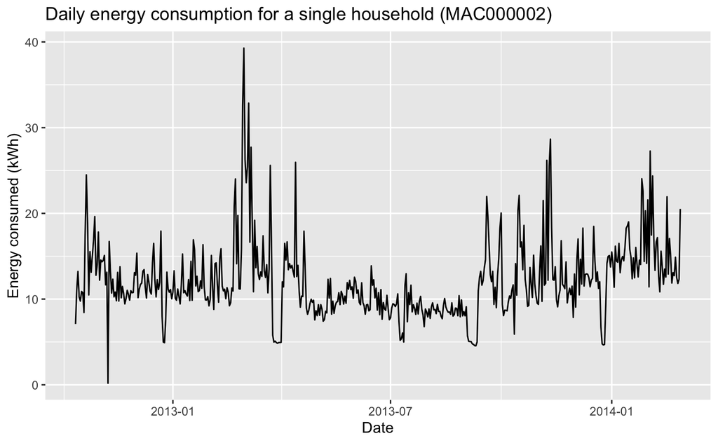

```r
daily_energy_clean %>%
  # mutate(is_weekend = (wday(date, label = TRUE, abbrev = TRUE) %in% c("Sat", "Sun")))
  filter(lc_lid == "MAC000002") %>%
  ggplot() +
  geom_line(aes(x = date, y = kwh)) +
  ggtitle("Daily energy consumption for a single household (MAC000002)") +
  ylab("Energy consumed (kWh)") + xlab("Date")
```

```r
# list hholds with more than 10% of data as 0 kWh
hholds_10pc_zero <- hhold_stats %>%
  filter(pc_zero_values > 10) %>%
  pull(lc_lid) # 73 hholds

# list hholds with fewer than 180 observations (6 months) in dataset
hholds_180obs <- hhold_stats %>%
  filter(!lc_lid %in% hholds_10pc_zero) %>%
  filter(num_values < 180) %>%
  pull(lc_lid) # 19 hholds

# create cleaned df (remove hholds with limited data or lots of zeros, trim dates)
daily_energy_clean <- daily_energy_trim %>%
  filter(!lc_lid %in% hholds_10pc_zero) %>%
  filter(!lc_lid %in% hholds_180obs)

num_hholds_og <- length(unique(daily_energy$lc_lid))
num_hholds_clean <- length(unique(daily_energy_clean$lc_lid))

num_hholds_og
```

```
[1] 5566
```

```r
num_hholds_clean
```

```
[1] 5474
```

```r
num_hholds_og - num_hholds_clean
```

```
[1] 92
```

```r
100* (num_hholds_og - num_hholds_clean) / num_hholds_og
```

```
[1] 1.652893
```

```r
skimr::skim(daily_energy_clean)
```

```
── Data Summary ────────────────────────
                           Values
Name                       daily_energy_clean
Number of rows             3466387
Number of columns          3
_______________________
Column type frequency:
  character                1
  Date                     1
  numeric                  1
________________________
Group variables            None
```

|  | skim_variable | n_missing | complete_rate | min | max | empty | n_unique | whitespace |
| --- | --- | --- | --- | --- | --- | --- | --- | --- |
| 1 | lc_lid | 0 | 1 | 9 | 9 | 0 | 5474 | 0 |

|  | skim_variable | n_missing | complete_rate | min | max | median | n_unique |
| --- | --- | --- | --- | --- | --- | --- | --- |
| 1 | date | 0 | 1 | 2011-12-01 | 2014-02-27 | 2013-03-30 | 820 |

|  | skim_variable | n_missing | complete_rate | mean | sd | p0 | p25 | p50 | p75 | p100 | hist |
| --- | --- | --- | --- | --- | --- | --- | --- | --- | --- | --- | --- |
| 1 | kwh | 0 | 1 | 10.20733 | 9.106821 | 0 | 4.76 | 7.881 | 12.636 | 332.556 | ▇▁▁▁▁ |

After cleaning: 92 households (1.6%) removed from data, leaving 5,474 households in “cleaned” data, across 820 days from 2011-12-01 to 2014-02-27, with varying numbers of households per day (note on-ramp at the beginning of the time period).

```r
# generate tsibble from cleaned data
daily_energy_ts <- as_tsibble(daily_energy_clean, key = lc_lid, index = date)
```

# Prelim

Brief: Using all households (n = 5,474; after cleaning), model expected average household consumption in future years.

## How to do test/train split?

Depends on amount of data!

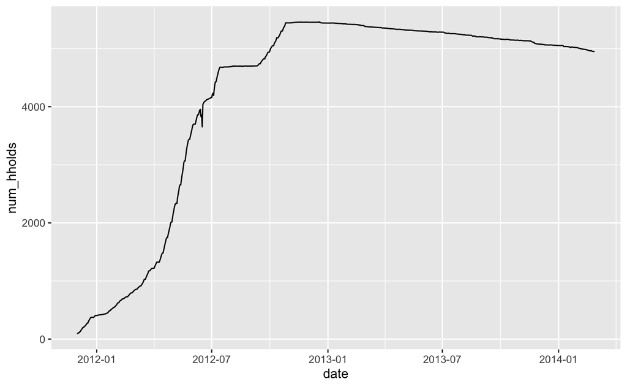

```r
num_hholds_by_date <- daily_energy_clean %>%
  group_by(date) %>%
  summarise(num_hholds = n())

num_hholds_by_date %>%
  ggplot() +
  geom_line(aes(x = date, y = num_hholds))
```

So there might not be enough data in early timeframe, or long enough time period, to do a split.

- Training: 2011-12-01 to 2013-10-31
- Test: 2013-11-01 to 2014-02-27

```r
start_date <- min(daily_energy_clean$date)
end_date <- max(daily_energy_clean$date)

train_length <- as.numeric(as_date("2013-10-31") - start_date + 1) # +1 inclusive dates
test_length <- as.numeric(end_date - as_date("2013-11-01") + 1)
pc_test <- 100 * test_length / (train_length + test_length)

train_length
```

```
[1] 701
```

```r
test_length
```

```
[1] 119
```

```r
# should sum to 820!
pc_test
```

```
[1] 14.5122
```

So this would mean forecasting for winter 2013, ~15% of the timeframe of the actual dataset, covering one winter season.

What would be the % data?

```r
test_data_len <- daily_energy_clean %>%
  filter(date >= "2013-11-01") %>%  # the test split
  nrow()
test_data_len
```

```
[1] 601038
```

```r
pc_test_data <- 100* test_data_len / nrow(daily_energy_clean)
pc_test_data
```

```
[1] 17.33903
```

601,038 observations in test set, 17.3% of overall observations across whole dataset.

So 2013-11-01 (as first date in test data) seems like an appropriate cut-off date for test/train split.

```r
# ~85% of the timeframe, just under 2 years of data
allhholds_forecast_train <- daily_energy_ts %>%
  filter_index(. ~ "2013-10-31")

# most recent 4 months
allhholds_forecast_test <- daily_energy_ts %>%
  filter_index("2013-11-01" ~ .)
```

### Other options to explore if this doesn’t work

*Q: can I test/train split the most recent year to have some training data but test on 20% households?* If so, how to pick the 20%? Could do random selection, but would I be missing a key stratification (e.g. high/medium/low consumers - could calculate from each household’s median: high >Q3 overall, low <Q1 overall, medium in Q1-Q3 overall range)

## How/what to model on?

From exploration:

- For a traditional forecast (1 value per day) - use median as average per day and per household due to not normal distribution?
- Or use all data available and do probabilistic forecasting – see work by Jethro Browell
- Visually, see seasonal pattern (high winter, low summer), weekday pattern (higher weekends that weekdays), and looks like energy consumption is reducing over time. – use seasonal models:
  - snaive
  - SARIMA
  - seasonal decomposition + any model - tbc

[output not shown]

[output cut: 990 more lines]

Use `autoplot()` to plot ts graph - but reduce rows first, otherwise R gets stuck!

**PAUSING** to pursue a different business question (characterising households by patterns of energy consumption)